# Data Science Capstone - Week 2

Alexander Zhou

2/18/2018

## Introduction

This is the milestone report of the Coursera Data Science Capstone Project. This document will cover the exploratory data analysis of the Swift data set and the natural language processing to tokenize n-grams as a first step toward building a predictive model.

## Dataset Information

The data sets are expected to be located in a parent directory called `Data`. Variables such as `dir.separator` should be changed below, depending on the platform.

```r
dir.separator <- "/"
swift.dir <- paste("..","Data", sep = dir.separator)
swift.lang <- "en_US"
swift.path <- paste(swift.dir, dir.separator, swift.lang, dir.separator, sep = "")
set.seed(2501)
sample.size <- 0.01
options(mc.cores = detectCores())
grams.n <- 20
```

Gathering some basic properties of the data set and combining all information into a tabular output.

```r
blogs <- readLines(paste(swift.path, swift.lang,".blogs.txt", sep = ""),
                         encoding = "UTF-8", skipNul = TRUE)
news <- readLines(paste(swift.path, swift.lang,".news.txt", sep = ""),
                        encoding = "UTF-8", skipNul = TRUE)
twitter <- readLines(paste(swift.path, swift.lang,".twitter.txt", sep = ""),
                           encoding = "UTF-8", skipNul = TRUE)

raw.stat <- data.frame(
            FileName=c(paste(swift.lang,".blogs.txt", sep = ""),
                       paste(swift.lang,".news.txt", sep = ""),
                       paste(swift.lang,".twitter.txt", sep = "")),
            FileSizeMB=c(file.info(paste(swift.path, swift.lang,".blogs.txt",
                                         sep = ""))$size/1024^2,
                         file.info(paste(swift.path, swift.lang,".news.txt",
                                         sep = ""))$size/1024^2,
                         file.info(paste(swift.path, swift.lang,".twitter.txt",
                                         sep = ""))$size/1024^2),
            t(rbind(sapply(list(blogs,news,twitter),stri_stats_general),
            wordCount=sapply(list(blogs,news,twitter),stri_stats_latex)[4,])))
kable(raw.stat)
```

| FileName | FileSizeMB | Lines | LinesNEmpty | Chars | CharsNWhite | wordCount |
| --- | --- | --- | --- | --- | --- | --- |
| en_US.blogs.txt | 200.4 | 899288 | 899288 | 206824382 | 170389539 | 37570839 |
| en_US.news.txt | 196.3 | 1010242 | 1010242 | 203223154 | 169860866 | 34494539 |
| en_US.twitter.txt | 159.4 | 2360148 | 2360148 | 162096241 | 134082806 | 30451170 |

A [list](https://www.freewebheaders.com/full-list-of-bad-words-banned-by-google/) of abusive words is used to filter out unwanted words form the database.

```r
if (!file.exists("abusive-words.txt")){
  download.file("https://www.freewebheaders.com/wordpress/wp-content/uploads/full-list-of-bad-words-banned-by-google-txt-file.zip", "abusive-words.zip")
  unzip("abusive-words.zip")
  file.rename("full-list-of-bad-words-banned-by-google-txt-file_2013_11_26_04_53_31_867.txt","abusive-words.txt", showWarnings = FALSE)
  file.remove("abusive-words.zip")
}
words.abusive <- readLines("abusive-words.txt", encoding="latin1", warn=FALSE, skipNul=TRUE)
```

```r
words.sample <- list(sample(blogs, length(blogs) * sample.size, replace=FALSE),
                     sample(news, length(news) * sample.size, replace=FALSE),
                     sample(twitter, length(twitter) * sample.size, replace=FALSE))

words.clean <- VCorpus(VectorSource(words.sample)) %>%
  tm_map(removeNumbers) %>%
  tm_map(removePunctuation) %>%
  tm_map(removeWords, stopwords("english")) %>%
  tm_map(removeWords, words.abusive) %>%
  tm_map(stripWhitespace) %>%
  tm_map(content_transformer(tolower)) %>%
  tm_map(PlainTextDocument)
```

The cleaned data can then be tokenized to generate n-grams.

```r
tokenizer <- function (x = words.clean, token) {
  NGramTokenizer(x, Weka_control(min = token, max = token))
}
```

Gathering and plotting the most frequent Unigrams.

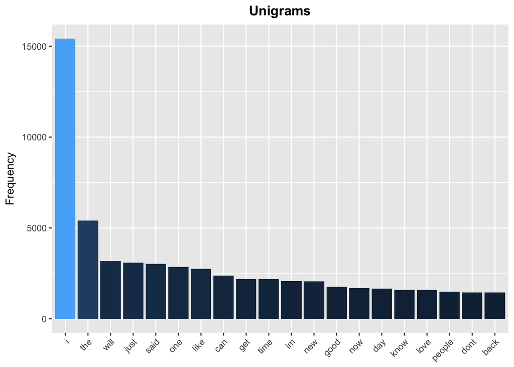

```r
gram.1 <- data.frame(table(tokenizer(words.clean, 1)))
gram.1 <- gram.1[order(gram.1$Freq, decreasing = TRUE),]
colnames(gram.1) <- c("Word", "Freq")
gram.1 <- head(gram.1, grams.n)
ggplot(gram.1, aes(x=reorder(Word, -Freq), y = Freq)) +
  geom_bar(stat="identity", aes(fill=Freq)) +
  ggtitle("Unigrams") + ylab("Frequency") + theme(axis.title.x=element_blank()) +
  theme(axis.text.x = element_text(angle = 45, hjust = 1)) +
  theme(plot.title = element_text(hjust = 0.5)) +
  theme(plot.title = element_text(lineheight=.8, face="bold")) +
  guides(fill=FALSE)
```

Same routine for the most frequent Bigrams.

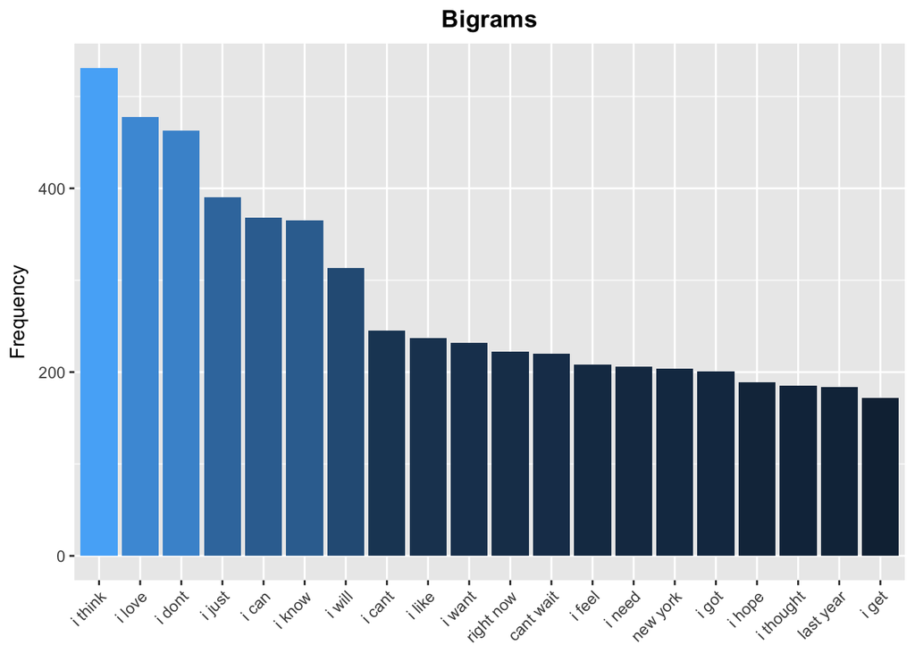

```r
gram.2 <- data.frame(table(tokenizer(words.clean, 2)))
gram.2 <- gram.2[order(gram.2$Freq, decreasing = TRUE),]
colnames(gram.2) <- c("Word", "Freq")
gram.2 <- head(gram.2, grams.n)
ggplot(gram.2, aes(x=reorder(Word, -Freq), y = Freq)) +
  geom_bar(stat="identity", aes(fill=Freq)) +
  ggtitle("Bigrams") + ylab("Frequency") + theme(axis.title.x=element_blank()) +
  theme(axis.text.x = element_text(angle = 45, hjust = 1)) +
  theme(plot.title = element_text(hjust = 0.5)) +
  theme(plot.title = element_text(lineheight=.8, face="bold")) +
  guides(fill=FALSE)
```

Most frequent Trigrams tokenization and plotting.

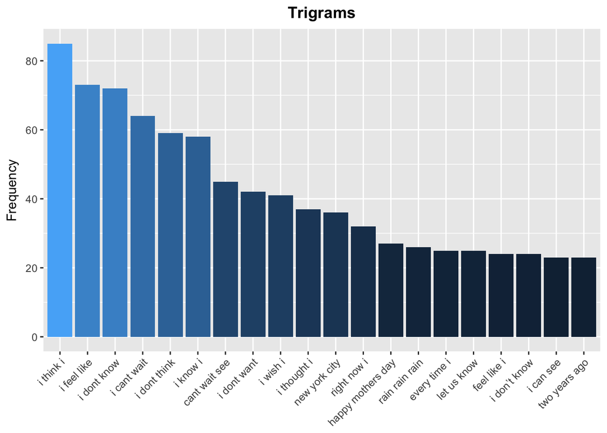

```r
gram.3 <- data.frame(table(tokenizer(words.clean, 3)))
gram.3 <- gram.3[order(gram.3$Freq, decreasing = TRUE),]
colnames(gram.3) <- c("Word", "Freq")
gram.3 <- head(gram.3, grams.n)
ggplot(gram.3, aes(x=reorder(Word, -Freq), y = Freq)) +
  geom_bar(stat="identity", aes(fill=Freq)) +
  ggtitle("Trigrams") + ylab("Frequency") + theme(axis.title.x=element_blank()) +
  theme(axis.text.x = element_text(angle = 45, hjust = 1)) +
  theme(plot.title = element_text(hjust = 0.5)) +
  theme(plot.title = element_text(lineheight=.8, face="bold")) +
  guides(fill=FALSE)
```

## Next Steps

Starting with this exploratory analysis, the next step would be building the predictive model using the token data and doing a frequency lookup. The final model should consider a bigger chunk of the data. The final algorithm will be tested and deployed as Shiny app.